# Risk Factor Analysis

## Outcome Variable

**Outcome Variable:** ever_stunted

## Predictor Variables

**Intervention Variable:** predexfd6

**Adjustment Set:**

- arm
- sex
- brthmon
- W_mage
- meducyrs
- feducyrs
- hhwealth_quart
- hfoodsec
- W_mhtcm
- W_mwtkg
- W_mbmi
- vagbrth
- W_gagebrth
- W_birthwt
- W_birthlen
- W_nrooms
- W_nchldlt5
- month
- W_parity
- impfloor
- impsan
- safeh20
- delta_W_mage
- delta_meducyrs
- delta_feducyrs
- delta_hhwealth_quart
- delta_hfoodsec
- delta_W_mhtcm
- delta_W_mwtkg
- delta_W_mbmi
- delta_vagbrth
- delta_W_gagebrth
- delta_W_birthwt
- delta_W_birthlen
- delta_W_nrooms
- delta_W_nchldlt5
- delta_month
- delta_W_parity
- delta_impfloor
- delta_impsan
- delta_safeh20

## Stratifying Variables

The analysis was stratified on these variable(s):

- agecat
- studyid
- country

## Data Summary

| agecat | studyid | country | predexfd6 | ever_stunted | n_cell | n |
| --- | --- | --- | --- | --- | --- | --- |
| 0-24 months (no birth st.) | CMC-V-BCS-2002 | INDIA | 1 | 0 | 1 | 14 |
| 0-24 months (no birth st.) | CMC-V-BCS-2002 | INDIA | 1 | 1 | 13 | 14 |
| 0-24 months (no birth st.) | CMC-V-BCS-2002 | INDIA | 0 | 0 | 0 | 14 |
| 0-24 months (no birth st.) | CMC-V-BCS-2002 | INDIA | 0 | 1 | 0 | 14 |
| 0-24 months (no birth st.) | EE | PAKISTAN | 1 | 0 | 4 | 27 |
| 0-24 months (no birth st.) | EE | PAKISTAN | 1 | 1 | 19 | 27 |
| 0-24 months (no birth st.) | EE | PAKISTAN | 0 | 0 | 2 | 27 |
| 0-24 months (no birth st.) | EE | PAKISTAN | 0 | 1 | 2 | 27 |
| 0-24 months (no birth st.) | GMS-Nepal | NEPAL | 1 | 0 | 130 | 471 |
| 0-24 months (no birth st.) | GMS-Nepal | NEPAL | 1 | 1 | 222 | 471 |
| 0-24 months (no birth st.) | GMS-Nepal | NEPAL | 0 | 0 | 34 | 471 |
| 0-24 months (no birth st.) | GMS-Nepal | NEPAL | 0 | 1 | 85 | 471 |
| 0-24 months (no birth st.) | IRC | INDIA | 1 | 0 | 0 | 13 |
| 0-24 months (no birth st.) | IRC | INDIA | 1 | 1 | 0 | 13 |
| 0-24 months (no birth st.) | IRC | INDIA | 0 | 0 | 4 | 13 |
| 0-24 months (no birth st.) | IRC | INDIA | 0 | 1 | 9 | 13 |
| 0-24 months (no birth st.) | JiVitA-3 | BANGLADESH | 1 | 0 | 6247 | 10809 |
| 0-24 months (no birth st.) | JiVitA-3 | BANGLADESH | 1 | 1 | 2191 | 10809 |
| 0-24 months (no birth st.) | JiVitA-3 | BANGLADESH | 0 | 0 | 1776 | 10809 |
| 0-24 months (no birth st.) | JiVitA-3 | BANGLADESH | 0 | 1 | 595 | 10809 |
| 0-24 months (no birth st.) | JiVitA-4 | BANGLADESH | 1 | 0 | 1565 | 3397 |
| 0-24 months (no birth st.) | JiVitA-4 | BANGLADESH | 1 | 1 | 1125 | 3397 |
| 0-24 months (no birth st.) | JiVitA-4 | BANGLADESH | 0 | 0 | 393 | 3397 |
| 0-24 months (no birth st.) | JiVitA-4 | BANGLADESH | 0 | 1 | 314 | 3397 |
| 0-24 months (no birth st.) | Keneba | GAMBIA | 1 | 0 | 401 | 2023 |
| 0-24 months (no birth st.) | Keneba | GAMBIA | 1 | 1 | 350 | 2023 |
| 0-24 months (no birth st.) | Keneba | GAMBIA | 0 | 0 | 566 | 2023 |
| 0-24 months (no birth st.) | Keneba | GAMBIA | 0 | 1 | 706 | 2023 |
| 0-24 months (no birth st.) | LCNI-5 | MALAWI | 1 | 0 | 18 | 175 |
| 0-24 months (no birth st.) | LCNI-5 | MALAWI | 1 | 1 | 12 | 175 |

[output cut: 114 more lines]

The following strata were considered:

- agecat: 0-24 months (no birth st.), studyid: CMC-V-BCS-2002, country: INDIA
- agecat: 0-24 months (no birth st.), studyid: EE, country: PAKISTAN
- agecat: 0-24 months (no birth st.), studyid: GMS-Nepal, country: NEPAL
- agecat: 0-24 months (no birth st.), studyid: IRC, country: INDIA
- agecat: 0-24 months (no birth st.), studyid: JiVitA-3, country: BANGLADESH
- agecat: 0-24 months (no birth st.), studyid: JiVitA-4, country: BANGLADESH
- agecat: 0-24 months (no birth st.), studyid: Keneba, country: GAMBIA
- agecat: 0-24 months (no birth st.), studyid: LCNI-5, country: MALAWI
- agecat: 0-24 months (no birth st.), studyid: MAL-ED, country: BANGLADESH
- agecat: 0-24 months (no birth st.), studyid: MAL-ED, country: BRAZIL
- agecat: 0-24 months (no birth st.), studyid: MAL-ED, country: INDIA
- agecat: 0-24 months (no birth st.), studyid: MAL-ED, country: NEPAL
- agecat: 0-24 months (no birth st.), studyid: MAL-ED, country: PERU
- agecat: 0-24 months (no birth st.), studyid: MAL-ED, country: SOUTH AFRICA
- agecat: 0-24 months (no birth st.), studyid: MAL-ED, country: TANZANIA, UNITED REPUBLIC OF
- agecat: 0-24 months (no birth st.), studyid: PROVIDE, country: BANGLADESH
- agecat: 0-24 months (no birth st.), studyid: SAS-CompFeed, country: INDIA
- agecat: 0-24 months (no birth st.), studyid: SAS-FoodSuppl, country: INDIA
- agecat: 0-6 months (no birth st.), studyid: CMC-V-BCS-2002, country: INDIA
- agecat: 0-6 months (no birth st.), studyid: EE, country: PAKISTAN
- agecat: 0-6 months (no birth st.), studyid: GMS-Nepal, country: NEPAL
- agecat: 0-6 months (no birth st.), studyid: IRC, country: INDIA
- agecat: 0-6 months (no birth st.), studyid: JiVitA-3, country: BANGLADESH
- agecat: 0-6 months (no birth st.), studyid: JiVitA-4, country: BANGLADESH
- agecat: 0-6 months (no birth st.), studyid: Keneba, country: GAMBIA
- agecat: 0-6 months (no birth st.), studyid: LCNI-5, country: MALAWI
- agecat: 0-6 months (no birth st.), studyid: MAL-ED, country: BANGLADESH
- agecat: 0-6 months (no birth st.), studyid: MAL-ED, country: BRAZIL
- agecat: 0-6 months (no birth st.), studyid: MAL-ED, country: INDIA
- agecat: 0-6 months (no birth st.), studyid: MAL-ED, country: NEPAL
- agecat: 0-6 months (no birth st.), studyid: MAL-ED, country: PERU
- agecat: 0-6 months (no birth st.), studyid: MAL-ED, country: SOUTH AFRICA
- agecat: 0-6 months (no birth st.), studyid: MAL-ED, country: TANZANIA, UNITED REPUBLIC OF
- agecat: 0-6 months (no birth st.), studyid: PROVIDE, country: BANGLADESH
- agecat: 0-6 months (no birth st.), studyid: SAS-CompFeed, country: INDIA
- agecat: 0-6 months (no birth st.), studyid: SAS-FoodSuppl, country: INDIA

### Dropped Strata

Some strata were dropped due to rare outcomes:

- agecat: 0-24 months (no birth st.), studyid: CMC-V-BCS-2002, country: INDIA
- agecat: 0-24 months (no birth st.), studyid: EE, country: PAKISTAN
- agecat: 0-24 months (no birth st.), studyid: IRC, country: INDIA
- agecat: 0-24 months (no birth st.), studyid: MAL-ED, country: BRAZIL
- agecat: 0-24 months (no birth st.), studyid: MAL-ED, country: INDIA
- agecat: 0-24 months (no birth st.), studyid: MAL-ED, country: SOUTH AFRICA
- agecat: 0-24 months (no birth st.), studyid: MAL-ED, country: TANZANIA, UNITED REPUBLIC OF
- agecat: 0-24 months (no birth st.), studyid: SAS-FoodSuppl, country: INDIA
- agecat: 0-6 months (no birth st.), studyid: CMC-V-BCS-2002, country: INDIA
- agecat: 0-6 months (no birth st.), studyid: EE, country: PAKISTAN
- agecat: 0-6 months (no birth st.), studyid: IRC, country: INDIA
- agecat: 0-6 months (no birth st.), studyid: LCNI-5, country: MALAWI
- agecat: 0-6 months (no birth st.), studyid: MAL-ED, country: BRAZIL
- agecat: 0-6 months (no birth st.), studyid: MAL-ED, country: INDIA
- agecat: 0-6 months (no birth st.), studyid: MAL-ED, country: NEPAL
- agecat: 0-6 months (no birth st.), studyid: MAL-ED, country: SOUTH AFRICA
- agecat: 0-6 months (no birth st.), studyid: MAL-ED, country: TANZANIA, UNITED REPUBLIC OF
- agecat: 0-6 months (no birth st.), studyid: SAS-FoodSuppl, country: INDIA

## Methods Detail

We're interested in the causal parameters $E[Y_a]$ for all values of $a \in \mathcal{A}$. These parameters represent the mean outcome if, possibly contrary to fact, we intervened to set all units to have $A=a$. Under the randomization and positivity assumptions, these are identified by the statistical parameters $\psi_a=E_W[E_{Y|A,W}(Y|A=a,W)]$. In addition, we're interested in the mean of $Y$, $E[Y]$ under no intervention (the observed mean). We will estimate these parameters by using SuperLearner to fit the relevant likelihood factors -- $E_{Y|A,W}(Y|A=a,W)$ and $p(A=a|W)$, and then updating our likelihood fit using a joint TMLE.

For unadjusted analyses ($W=\{\}$), initial likelihoods were estimated using Lrnr_glm to estimate the simple $E(Y|A)$ and Lrnr_mean to estimate $p(A)$. For adjusted analyses, a small library containing Lrnr_glmnet, Lrnr_xgboost, and Lrnr_mean was used.

Having estimated these parameters, we will then use the delta method to estimate relative risks and attributable risks relative to a prespecified baseline level of $A$.

# Results Detail

## Results Plots

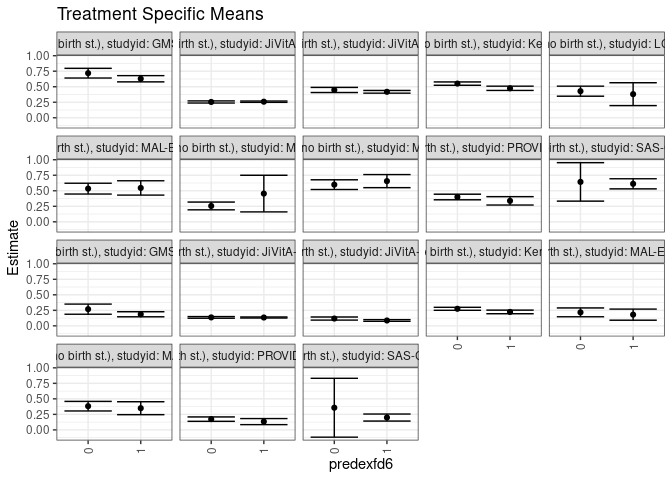

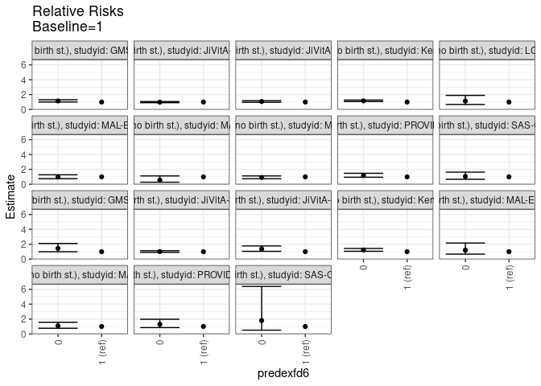

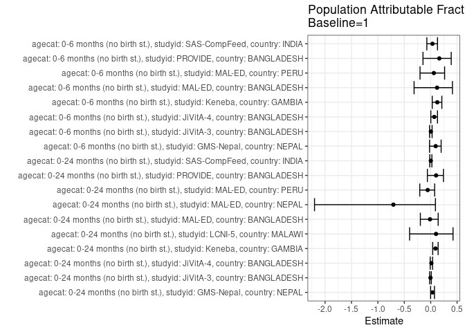

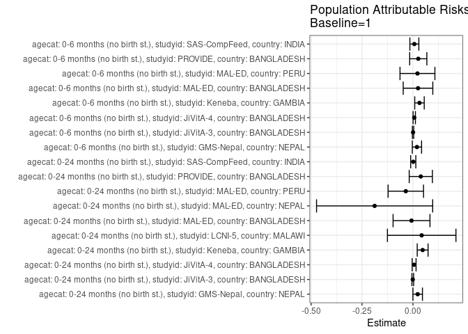

## Results Table

### Parameter: TSM

| agecat | studyid | country | intervention_level | baseline_level | estimate | ci_lower | ci_upper |
| --- | --- | --- | --- | --- | --- | --- | --- |
| 0-24 months (no birth st.) | GMS-Nepal | NEPAL | 1 | NA | 0.6286987 | 0.5783836 | 0.6790138 |
| 0-24 months (no birth st.) | GMS-Nepal | NEPAL | 0 | NA | 0.7184072 | 0.6403737 | 0.7964406 |
| 0-24 months (no birth st.) | JiVitA-3 | BANGLADESH | 1 | NA | 0.2587978 | 0.2477527 | 0.2698429 |
| 0-24 months (no birth st.) | JiVitA-3 | BANGLADESH | 0 | NA | 0.2543479 | 0.2374219 | 0.2712740 |
| 0-24 months (no birth st.) | JiVitA-4 | BANGLADESH | 1 | NA | 0.4180674 | 0.3962524 | 0.4398823 |
| 0-24 months (no birth st.) | JiVitA-4 | BANGLADESH | 0 | NA | 0.4477044 | 0.4063399 | 0.4890689 |
| 0-24 months (no birth st.) | Keneba | GAMBIA | 1 | NA | 0.4745582 | 0.4402027 | 0.5089138 |
| 0-24 months (no birth st.) | Keneba | GAMBIA | 0 | NA | 0.5504537 | 0.5236728 | 0.5772345 |
| 0-24 months (no birth st.) | LCNI-5 | MALAWI | 1 | NA | 0.3801152 | 0.1959630 | 0.5642673 |
| 0-24 months (no birth st.) | LCNI-5 | MALAWI | 0 | NA | 0.4282439 | 0.3473514 | 0.5091364 |
| 0-24 months (no birth st.) | MAL-ED | BANGLADESH | 1 | NA | 0.5456102 | 0.4302585 | 0.6609618 |
| 0-24 months (no birth st.) | MAL-ED | BANGLADESH | 0 | NA | 0.5344552 | 0.4476781 | 0.6212323 |
| 0-24 months (no birth st.) | MAL-ED | NEPAL | 1 | NA | 0.4545455 | 0.1595511 | 0.7495398 |
| 0-24 months (no birth st.) | MAL-ED | NEPAL | 0 | NA | 0.2553191 | 0.1928321 | 0.3178062 |
| 0-24 months (no birth st.) | MAL-ED | PERU | 1 | NA | 0.6554461 | 0.5501043 | 0.7607880 |
| 0-24 months (no birth st.) | MAL-ED | PERU | 0 | NA | 0.5983790 | 0.5201371 | 0.6766209 |
| 0-24 months (no birth st.) | PROVIDE | BANGLADESH | 1 | NA | 0.3375813 | 0.2700408 | 0.4051217 |
| 0-24 months (no birth st.) | PROVIDE | BANGLADESH | 0 | NA | 0.3995947 | 0.3543447 | 0.4448447 |
| 0-24 months (no birth st.) | SAS-CompFeed | INDIA | 1 | NA | 0.6121795 | 0.5306906 | 0.6936683 |
| 0-24 months (no birth st.) | SAS-CompFeed | INDIA | 0 | NA | 0.6428571 | 0.3329177 | 0.9527966 |
| 0-6 months (no birth st.) | GMS-Nepal | NEPAL | 1 | NA | 0.1865160 | 0.1456283 | 0.2274037 |
| 0-6 months (no birth st.) | GMS-Nepal | NEPAL | 0 | NA | 0.2688992 | 0.1872447 | 0.3505538 |
| 0-6 months (no birth st.) | JiVitA-3 | BANGLADESH | 1 | NA | 0.1342549 | 0.1260159 | 0.1424939 |
| 0-6 months (no birth st.) | JiVitA-3 | BANGLADESH | 0 | NA | 0.1358663 | 0.1228710 | 0.1488615 |
| 0-6 months (no birth st.) | JiVitA-4 | BANGLADESH | 1 | NA | 0.0863538 | 0.0728328 | 0.0998748 |
| 0-6 months (no birth st.) | JiVitA-4 | BANGLADESH | 0 | NA | 0.1174786 | 0.0925169 | 0.1424402 |
| 0-6 months (no birth st.) | Keneba | GAMBIA | 1 | NA | 0.2240900 | 0.1949699 | 0.2532101 |
| 0-6 months (no birth st.) | Keneba | GAMBIA | 0 | NA | 0.2747964 | 0.2506663 | 0.2989265 |
| 0-6 months (no birth st.) | MAL-ED | BANGLADESH | 1 | NA | 0.1804212 | 0.0908792 | 0.2699632 |
| 0-6 months (no birth st.) | MAL-ED | BANGLADESH | 0 | NA | 0.2173067 | 0.1459979 | 0.2886156 |
| 0-6 months (no birth st.) | MAL-ED | PERU | 1 | NA | 0.3493117 | 0.2449398 | 0.4536835 |
| 0-6 months (no birth st.) | MAL-ED | PERU | 0 | NA | 0.3819517 | 0.3050682 | 0.4588352 |
| 0-6 months (no birth st.) | PROVIDE | BANGLADESH | 1 | NA | 0.1335619 | 0.0846092 | 0.1825147 |
| 0-6 months (no birth st.) | PROVIDE | BANGLADESH | 0 | NA | 0.1732109 | 0.1378553 | 0.2085665 |
| 0-6 months (no birth st.) | SAS-CompFeed | INDIA | 1 | NA | 0.1987179 | 0.1419130 | 0.2555229 |
| 0-6 months (no birth st.) | SAS-CompFeed | INDIA | 0 | NA | 0.3571429 | -0.1170496 | 0.8313354 |

### Parameter: E(Y)

| agecat | studyid | country | intervention_level | baseline_level | estimate | ci_lower | ci_upper |
| --- | --- | --- | --- | --- | --- | --- | --- |
| 0-24 months (no birth st.) | GMS-Nepal | NEPAL | NA | NA | 0.6518047 | 0.6087352 | 0.6948741 |
| 0-24 months (no birth st.) | JiVitA-3 | BANGLADESH | NA | NA | 0.2577482 | 0.2478575 | 0.2676389 |
| 0-24 months (no birth st.) | JiVitA-4 | BANGLADESH | NA | NA | 0.4236091 | 0.4038600 | 0.4433581 |
| 0-24 months (no birth st.) | Keneba | GAMBIA | NA | NA | 0.5219970 | 0.5002246 | 0.5437695 |
| 0-24 months (no birth st.) | LCNI-5 | MALAWI | NA | NA | 0.4228571 | 0.3494545 | 0.4962598 |
| 0-24 months (no birth st.) | MAL-ED | BANGLADESH | NA | NA | 0.5384615 | 0.4683114 | 0.6086117 |
| 0-24 months (no birth st.) | MAL-ED | NEPAL | NA | NA | 0.2663317 | 0.2047606 | 0.3279027 |
| 0-24 months (no birth st.) | MAL-ED | PERU | NA | NA | 0.6202532 | 0.5583342 | 0.6821721 |
| 0-24 months (no birth st.) | PROVIDE | BANGLADESH | NA | NA | 0.3759874 | 0.3382238 | 0.4137509 |
| 0-24 months (no birth st.) | SAS-CompFeed | INDIA | NA | NA | 0.6134969 | 0.5286303 | 0.6983636 |
| 0-6 months (no birth st.) | GMS-Nepal | NEPAL | NA | NA | 0.2059448 | 0.1693853 | 0.2425043 |
| 0-6 months (no birth st.) | JiVitA-3 | BANGLADESH | NA | NA | 0.1346474 | 0.1274032 | 0.1418916 |
| 0-6 months (no birth st.) | JiVitA-4 | BANGLADESH | NA | NA | 0.0926091 | 0.0806150 | 0.1046031 |
| 0-6 months (no birth st.) | Keneba | GAMBIA | NA | NA | 0.2560554 | 0.2370317 | 0.2750791 |
| 0-6 months (no birth st.) | MAL-ED | BANGLADESH | NA | NA | 0.2051282 | 0.1483073 | 0.2619492 |
| 0-6 months (no birth st.) | MAL-ED | PERU | NA | NA | 0.3713080 | 0.3096658 | 0.4329502 |
| 0-6 months (no birth st.) | PROVIDE | BANGLADESH | NA | NA | 0.1595577 | 0.1310079 | 0.1881074 |
| 0-6 months (no birth st.) | SAS-CompFeed | INDIA | NA | NA | 0.2055215 | 0.1385538 | 0.2724891 |

### Parameter: RR

| agecat | studyid | country | intervention_level | baseline_level | estimate | ci_lower | ci_upper |
| --- | --- | --- | --- | --- | --- | --- | --- |
| 0-24 months (no birth st.) | GMS-Nepal | NEPAL | 1 | 1 | 1.0000000 | 1.0000000 | 1.000000 |
| 0-24 months (no birth st.) | GMS-Nepal | NEPAL | 0 | 1 | 1.1426891 | 1.0007374 | 1.304776 |
| 0-24 months (no birth st.) | JiVitA-3 | BANGLADESH | 1 | 1 | 1.0000000 | 1.0000000 | 1.000000 |
| 0-24 months (no birth st.) | JiVitA-3 | BANGLADESH | 0 | 1 | 0.9828055 | 0.9132608 | 1.057646 |
| 0-24 months (no birth st.) | JiVitA-4 | BANGLADESH | 1 | 1 | 1.0000000 | 1.0000000 | 1.000000 |
| 0-24 months (no birth st.) | JiVitA-4 | BANGLADESH | 0 | 1 | 1.0708905 | 0.9661707 | 1.186961 |
| 0-24 months (no birth st.) | Keneba | GAMBIA | 1 | 1 | 1.0000000 | 1.0000000 | 1.000000 |
| 0-24 months (no birth st.) | Keneba | GAMBIA | 0 | 1 | 1.1599286 | 1.0658518 | 1.262309 |
| 0-24 months (no birth st.) | LCNI-5 | MALAWI | 1 | 1 | 1.0000000 | 1.0000000 | 1.000000 |
| 0-24 months (no birth st.) | LCNI-5 | MALAWI | 0 | 1 | 1.1266162 | 0.6696498 | 1.895415 |
| 0-24 months (no birth st.) | MAL-ED | BANGLADESH | 1 | 1 | 1.0000000 | 1.0000000 | 1.000000 |
| 0-24 months (no birth st.) | MAL-ED | BANGLADESH | 0 | 1 | 0.9795551 | 0.7533985 | 1.273600 |
| 0-24 months (no birth st.) | MAL-ED | NEPAL | 1 | 1 | 1.0000000 | 1.0000000 | 1.000000 |
| 0-24 months (no birth st.) | MAL-ED | NEPAL | 0 | 1 | 0.5617021 | 0.2807235 | 1.123915 |
| 0-24 months (no birth st.) | MAL-ED | PERU | 1 | 1 | 1.0000000 | 1.0000000 | 1.000000 |
| 0-24 months (no birth st.) | MAL-ED | PERU | 0 | 1 | 0.9129339 | 0.7420469 | 1.123175 |
| 0-24 months (no birth st.) | PROVIDE | BANGLADESH | 1 | 1 | 1.0000000 | 1.0000000 | 1.000000 |
| 0-24 months (no birth st.) | PROVIDE | BANGLADESH | 0 | 1 | 1.1836992 | 0.9463807 | 1.480529 |
| 0-24 months (no birth st.) | SAS-CompFeed | INDIA | 1 | 1 | 1.0000000 | 1.0000000 | 1.000000 |
| 0-24 months (no birth st.) | SAS-CompFeed | INDIA | 0 | 1 | 1.0501122 | 0.6736522 | 1.636951 |
| 0-6 months (no birth st.) | GMS-Nepal | NEPAL | 1 | 1 | 1.0000000 | 1.0000000 | 1.000000 |
| 0-6 months (no birth st.) | GMS-Nepal | NEPAL | 0 | 1 | 1.4416950 | 0.9914230 | 2.096466 |
| 0-6 months (no birth st.) | JiVitA-3 | BANGLADESH | 1 | 1 | 1.0000000 | 1.0000000 | 1.000000 |
| 0-6 months (no birth st.) | JiVitA-3 | BANGLADESH | 0 | 1 | 1.0120025 | 0.9072048 | 1.128906 |
| 0-6 months (no birth st.) | JiVitA-4 | BANGLADESH | 1 | 1 | 1.0000000 | 1.0000000 | 1.000000 |
| 0-6 months (no birth st.) | JiVitA-4 | BANGLADESH | 0 | 1 | 1.3604335 | 1.0460045 | 1.769380 |
| 0-6 months (no birth st.) | Keneba | GAMBIA | 1 | 1 | 1.0000000 | 1.0000000 | 1.000000 |
| 0-6 months (no birth st.) | Keneba | GAMBIA | 0 | 1 | 1.2262769 | 1.0523073 | 1.429007 |
| 0-6 months (no birth st.) | MAL-ED | BANGLADESH | 1 | 1 | 1.0000000 | 1.0000000 | 1.000000 |
| 0-6 months (no birth st.) | MAL-ED | BANGLADESH | 0 | 1 | 1.2044414 | 0.6714215 | 2.160609 |
| 0-6 months (no birth st.) | MAL-ED | PERU | 1 | 1 | 1.0000000 | 1.0000000 | 1.000000 |
| 0-6 months (no birth st.) | MAL-ED | PERU | 0 | 1 | 1.0934410 | 0.7622902 | 1.568449 |
| 0-6 months (no birth st.) | PROVIDE | BANGLADESH | 1 | 1 | 1.0000000 | 1.0000000 | 1.000000 |
| 0-6 months (no birth st.) | PROVIDE | BANGLADESH | 0 | 1 | 1.2968581 | 0.8533187 | 1.970941 |
| 0-6 months (no birth st.) | SAS-CompFeed | INDIA | 1 | 1 | 1.0000000 | 1.0000000 | 1.000000 |
| 0-6 months (no birth st.) | SAS-CompFeed | INDIA | 0 | 1 | 1.7972350 | 0.5064696 | 6.377587 |

### Parameter: PAR

| agecat | studyid | country | intervention_level | baseline_level | estimate | ci_lower | ci_upper |
| --- | --- | --- | --- | --- | --- | --- | --- |
| 0-24 months (no birth st.) | GMS-Nepal | NEPAL | 1 | NA | 0.0231059 | -0.0003020 | 0.0465139 |
| 0-24 months (no birth st.) | JiVitA-3 | BANGLADESH | 1 | NA | -0.0010497 | -0.0051705 | 0.0030712 |
| 0-24 months (no birth st.) | JiVitA-4 | BANGLADESH | 1 | NA | 0.0055417 | -0.0040528 | 0.0151362 |
| 0-24 months (no birth st.) | Keneba | GAMBIA | 1 | NA | 0.0474388 | 0.0208079 | 0.0740697 |
| 0-24 months (no birth st.) | LCNI-5 | MALAWI | 1 | NA | 0.0427420 | -0.1253543 | 0.2108382 |
| 0-24 months (no birth st.) | MAL-ED | BANGLADESH | 1 | NA | -0.0071486 | -0.0976221 | 0.0833248 |
| 0-24 months (no birth st.) | MAL-ED | NEPAL | 1 | NA | -0.1882138 | -0.4731562 | 0.0967286 |
| 0-24 months (no birth st.) | MAL-ED | PERU | 1 | NA | -0.0351930 | -0.1221054 | 0.0517195 |
| 0-24 months (no birth st.) | PROVIDE | BANGLADESH | 1 | NA | 0.0384061 | -0.0184446 | 0.0952568 |
| 0-24 months (no birth st.) | SAS-CompFeed | INDIA | 1 | NA | 0.0013174 | -0.0112602 | 0.0138950 |
| 0-6 months (no birth st.) | GMS-Nepal | NEPAL | 1 | NA | 0.0194288 | -0.0033192 | 0.0421767 |
| 0-6 months (no birth st.) | JiVitA-3 | BANGLADESH | 1 | NA | 0.0003926 | -0.0028532 | 0.0036383 |
| 0-6 months (no birth st.) | JiVitA-4 | BANGLADESH | 1 | NA | 0.0062553 | 0.0005332 | 0.0119774 |
| 0-6 months (no birth st.) | Keneba | GAMBIA | 1 | NA | 0.0319654 | 0.0086628 | 0.0552679 |
| 0-6 months (no birth st.) | MAL-ED | BANGLADESH | 1 | NA | 0.0247070 | -0.0478823 | 0.0972963 |
| 0-6 months (no birth st.) | MAL-ED | PERU | 1 | NA | 0.0219963 | -0.0636354 | 0.1076281 |
| 0-6 months (no birth st.) | PROVIDE | BANGLADESH | 1 | NA | 0.0259957 | -0.0160581 | 0.0680496 |
| 0-6 months (no birth st.) | SAS-CompFeed | INDIA | 1 | NA | 0.0068035 | -0.0151879 | 0.0287949 |

### Parameter: PAF

| agecat | studyid | country | intervention_level | baseline_level | estimate | ci_lower | ci_upper |
| --- | --- | --- | --- | --- | --- | --- | --- |
| 0-24 months (no birth st.) | GMS-Nepal | NEPAL | 1 | NA | 0.0354492 | -0.0013741 | 0.0709183 |
| 0-24 months (no birth st.) | JiVitA-3 | BANGLADESH | 1 | NA | -0.0040724 | -0.0201749 | 0.0117760 |
| 0-24 months (no birth st.) | JiVitA-4 | BANGLADESH | 1 | NA | 0.0130821 | -0.0098274 | 0.0354718 |
| 0-24 months (no birth st.) | Keneba | GAMBIA | 1 | NA | 0.0908795 | 0.0382648 | 0.1406156 |
| 0-24 months (no birth st.) | LCNI-5 | MALAWI | 1 | NA | 0.1010789 | -0.3997678 | 0.4227192 |
| 0-24 months (no birth st.) | MAL-ED | BANGLADESH | 1 | NA | -0.0132761 | -0.1960103 | 0.1415389 |
| 0-24 months (no birth st.) | MAL-ED | NEPAL | 1 | NA | -0.7066895 | -2.2000739 | 0.0897744 |
| 0-24 months (no birth st.) | MAL-ED | PERU | 1 | NA | -0.0567397 | -0.2068839 | 0.0747256 |
| 0-24 months (no birth st.) | PROVIDE | BANGLADESH | 1 | NA | 0.1021473 | -0.0626734 | 0.2414043 |
| 0-24 months (no birth st.) | SAS-CompFeed | INDIA | 1 | NA | 0.0021474 | -0.0184658 | 0.0223435 |
| 0-6 months (no birth st.) | GMS-Nepal | NEPAL | 1 | NA | 0.0943397 | -0.0224947 | 0.1978242 |
| 0-6 months (no birth st.) | JiVitA-3 | BANGLADESH | 1 | NA | 0.0029154 | -0.0215013 | 0.0267485 |
| 0-6 months (no birth st.) | JiVitA-4 | BANGLADESH | 1 | NA | 0.0675453 | 0.0025878 | 0.1282724 |
| 0-6 months (no birth st.) | Keneba | GAMBIA | 1 | NA | 0.1248377 | 0.0290682 | 0.2111608 |
| 0-6 months (no birth st.) | MAL-ED | BANGLADESH | 1 | NA | 0.1204468 | -0.3146517 | 0.4115447 |
| 0-6 months (no birth st.) | MAL-ED | PERU | 1 | NA | 0.0592401 | -0.2020916 | 0.2637590 |
| 0-6 months (no birth st.) | PROVIDE | BANGLADESH | 1 | NA | 0.1629237 | -0.1459491 | 0.3885446 |
| 0-6 months (no birth st.) | SAS-CompFeed | INDIA | 1 | NA | 0.0331037 | -0.0733606 | 0.1290081 |